# Cell type annotation by supervised von Mises-Fisher clustering

Yongjin Park

2020-10-02 11:03:50

## Data preparation

We downloaded a list of PsychENCODE marker gene annotations (broad cell types). The file looks like this:

```bash
cat PsychENCODE.marker | head
```

```
## CBLN2    Ex
## ENC1 Ex
## AC011288.2   Ex
## TESPA1   Ex
## RP11-314P15.2    Ex
## LRRTM4   Ex
## LINC01378    Ex
## PDZD2    Ex
## FAM19A1  Ex
## HS6ST3   Ex
```

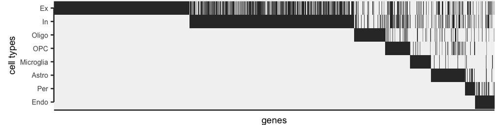

```r
marker.genes =
  fread("PsychENCODE.marker",header=FALSE) %>%
  (function(x) { colnames(x) = c("geneSymbol", "celltype"); x })

## just show these marker genes
.oo = list(rows = rev(c("Ex", "In", "Oligo", "OPC", "Microglia", "Astro", "Per", "Endo")))

.oo$cols =
    marker.genes %>%
    mutate(row = celltype, col = geneSymbol, weight = 1) %>%
    col.order(.oo$rows)

.df = marker.genes %>%
    mutate(row = factor(celltype, .oo$rows)) %>%
    mutate(col = factor(geneSymbol, .oo$cols))

.gg.plot(.df, aes(y=row, x=col)) +
    geom_tile() +
    xlab("genes") + ylab("cell types") +
    theme(axis.ticks.x=element_blank()) +
    theme(axis.text.x=element_blank())
```

For each cell, we can distinguish the identity of cell types by cosine similarity between them. For instance, we can construct a 0/1 marker gene membership matrix as follows:

```r
M = .df %>%
  select(celltype, geneSymbol) %>%
  mutate(val=1) %>%
  spread(key="celltype", value="val", fill=0) %>%
  select(-geneSymbol) %>%
  as.matrix

M %>% head
```

```
##      Astro Endo Ex In Microglia Oligo OPC Per
## [1,]     0    0  0  0         0     1   1   0
## [2,]     0    0  0  0         0     1   0   0
## [3,]     0    1  0  0         0     0   0   0
## [4,]     0    0  0  1         0     0   0   0
## [5,]     0    0  0  1         0     0   0   0
## [6,]     0    0  0  0         0     1   0   0
```

We can measure the cosine similarity across the columns by taking dot-product after normalization.

```r
M = apply(M, 2, function(x) x/sqrt(sum(x^2)))
t(M) %*% M %>% round(2)
```

```
##           Astro Endo   Ex   In Microglia Oligo  OPC  Per
## Astro      1.00 0.03 0.10 0.12      0.06  0.11 0.19 0.14
## Endo       0.03 1.00 0.05 0.05      0.03  0.04 0.01 0.32
## Ex         0.10 0.05 1.00 0.48      0.04  0.06 0.12 0.06
## In         0.12 0.05 0.48 1.00      0.04  0.08 0.20 0.07
## Microglia  0.06 0.03 0.04 0.04      1.00  0.08 0.08 0.03
## Oligo      0.11 0.04 0.06 0.08      0.08  1.00 0.16 0.09
## OPC        0.19 0.01 0.12 0.20      0.08  0.16 1.00 0.05
## Per        0.14 0.32 0.06 0.07      0.03  0.09 0.05 1.00
```

PsychENCODE’s marker gene selection might be imperfect since some “marker” genes are shared by different cell types. However, it has enough discriminatory power.

Using this initial dictionary of marker genes, we can start analyzing 10x data, which consist of these three files:

- Sparse count matrix:

```bash
gzip -cd data/brain_2018-05-03/filtered_count_matrix.mtx.gz | head
```

```
## %%MatrixMarket matrix coordinate integer general
## 17926 70634 119696200
## 56 1 1
## 139 1 1
## 270 1 1
## 324 1 1
## 375 1 1
## 389 1 1
## 420 1 1
## 557 1 1
```

- Cell barcode list:

```bash
gzip -cd data/brain_2018-05-03/barcodes.tsv.gz | head
```

```
## AAACGGGAGATCCCGC.1
## AAATGCCTCCAATGGT.1
## AACCATGTCAGTGCAT.1
## AACCATGTCTGTACGA.1
## AACCGCGTCCGCATAA.1
## AACGTTGGTTCAGGCC.1
## AACTGGTGTACCGGCT.1
## AAGACCTAGTTAACGA.1
## AAGGAGCAGCAATCTC.1
## AAGGAGCTCTGCTGCT.1
```

- Gene/feature list (**these names should exist in the marker file**):

```bash
gzip -cd data/brain_2018-05-03/features.tsv.gz | head
```

```
## FO538757.2
## SAMD11
## NOC2L
## KLHL17
## PLEKHN1
## PERM1
## HES4
## ISG15
## AGRN
## RNF223
```

## Annotate columns of 10x count matrix.

Let’s store all the results here:

```bash
[ -d example/annotate_brain ] || mkdir -p example/annotate_brain
```

Running this takes some time…

```bash
[ -f example/annotate_brain/out.annot.gz ] || \
    ../src/mmutil_annotate_col \
        --mtx data/brain_2018-05-03/filtered_count_matrix.mtx.gz \
        --feature data/brain_2018-05-03/features.tsv.gz \
        --balance_markers \
        --col data/brain_2018-05-03/barcodes.tsv.gz \
        --ann PsychENCODE.marker \
        --batch_size 1000 \
        --out example/annotate_brain/out 2> /dev/null
```

That is it! We have evaluated the probability of cell type assignment for these cells:

```bash
gzip -cd example/annotate_brain/out.annot.gz | head
```

```
## AAACGGGAGATCCCGC.1 Ex 0.999876 30.176
## AAATGCCTCCAATGGT.1 Ex 1 85.8104
## AACCATGTCAGTGCAT.1 Ex 0.999998 27.8746
## AACCATGTCTGTACGA.1 Ex 1 84.958
## AACCGCGTCCGCATAA.1 Ex 1 82.0054
## AACGTTGGTTCAGGCC.1 Ex 1 82.3728
## AACTGGTGTACCGGCT.1 Ex 1 85.6595
## AAGACCTAGTTAACGA.1 Ex 1 77.6316
## AAGGAGCAGCAATCTC.1 Ex 1 82.5496
## AAGGAGCTCTGCTGCT.1 Ex 1 85.3127
```

- The first column: barcode ID
- The second column: cell type provided by the `.marker` file
- The third column: the probability of most probable cell type

The algorithm iteratively adjust marker gene contribution:

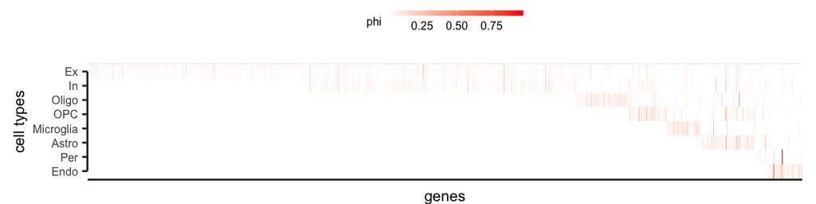

```r
.labels = fread("example/annotate_brain/out.label_names.gz",header=FALSE) %>% unlist

.genes = fread("example/annotate_brain/out.marker_names.gz",header=FALSE) %>% unlist

.df = fread("example/annotate_brain/out.marker_profile.gz") %>%
  (function(x) { colnames(x) = .labels; x }) %>%
  as_tibble() %>%
  mutate(geneSymbol = .genes) %>%
  gather(key=celltype, value=phi, -geneSymbol) %>%
  group_by(geneSymbol, celltype) %>%
  slice(which.max(phi)) %>%
  ungroup() %>%
  mutate(row = factor(celltype, .oo$rows)) %>%
  mutate(col = factor(geneSymbol, .oo$cols))

.gg.plot(.df, aes(y=row, x=col, fill = phi)) +
  theme(legend.position = "top") +
  geom_tile() +
  scale_fill_gradientn(colours=c("white", "red")) +
  xlab("genes") + ylab("cell types") +
  theme(axis.ticks.x=element_blank()) +
  theme(axis.text.x=element_blank())
```

## Embedding to show the cell type annotation result

```bash
[ -f example/annotate_brain/spectral.sample_factor.gz ] || \
    ../src/mmutil_spectral_col \
        --mtx data/brain_2018-05-03/filtered_count_matrix.mtx.gz \
        --rank 30 --em_iter 10 --em_tol 1e-4 --log_scale --block_size 1000 \
        --out example/annotate_brain/spectral 2> /dev/null
```

```r
.file = "example/annotate_brain/umap.gz"
if(!file.exists(.file)) {
    V = fread("example/annotate_brain/spectral.sample_factor.gz") %>% as.matrix
    uu.dt = uwot::umap(V, n_neighbors = 50,  n_threads = 16, verbose = TRUE) %>%
        as.data.table
    .fwrite(uu.dt, file=.file)
} else {
    uu.dt = fread(.file)
}
```

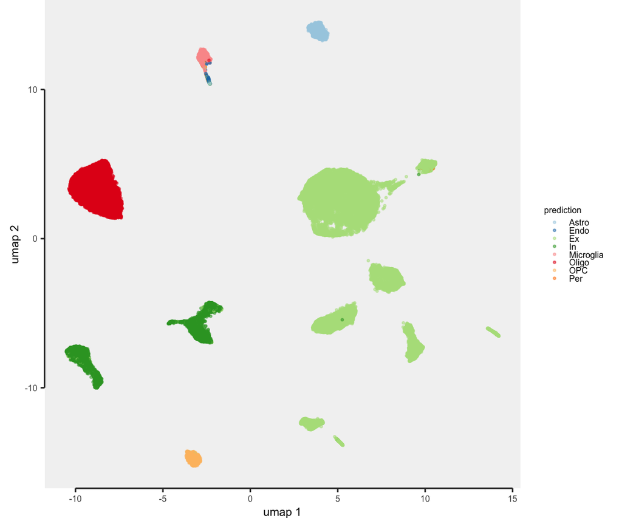

```r
.pred = fread("example/annotate_brain/out.annot.gz",header=FALSE)
colnames(.pred) = c("TAG", "prediction", "probability", "log.llik")
uu.dt = cbind(uu.dt, .pred)

.gg.plot(uu.dt, aes(x = V1, y = V2, color = prediction)) +
    xlab("umap 1") + ylab("umap 2") +
    geom_point(alpha = .5, size = .5) +
    scale_color_brewer("prediction", type="div", palette="Paired")
```